# *Activation Function*

## *Universal Approximation Theorem*

*Universal approximation theorem* *says:*

*that a feed-forward network with a single hidden layer containing a finite number of neurons can approximate continuous functions on compact subsets of R, under mild assumptions on the activation function — Wikipedia*

*In simple terms, UAT says that -* *you can always come up with a deep neural network that will approximate any complex relation between input and output.*

### *Proof of Universal Approximation Theorem*

*For this illustrative proof, we will consider a simple example where we have one-dimensional input x and output y, the graph shown below represents the true relationship between input and the output. Let’s assume that I don’t know what that function equation between x and y and I can’t come up with a representation for the equation.*

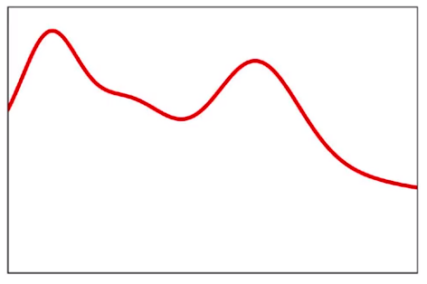

*To solve this problem, I will break this function into multiple smaller parts so that each part is represented by a simpler function. By combining the series of smaller functions (rectangular bars/towers) I can approximate the relation between x and y as close to the true relationship possible.*

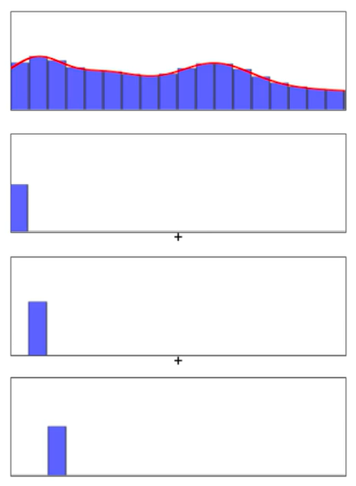

*The key point to note in this case is that I don’t have to worry about coming up with complex equations to represent the relationship between input and output. I can just come up with a simple function and use the combination of these functions to approximate the relationship to my true relationship. The more functions that I choose in this method the better will be my approximation.*

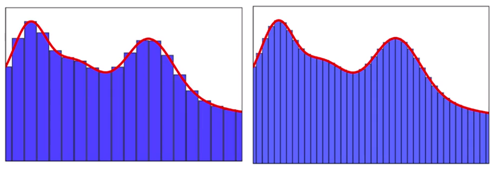

*How do we come up with these rectangles/towers and how it will tie back to the sigmoid neuron?*

*Let’s take two sigmoid functions having a very steep slope and notice that they have a different place at which they peak. The left sigmoid peaks just before zero and right sigmoid peaks just after zero. If I just subtract these two functions the net effect is going to be a tower (rectangular output).*

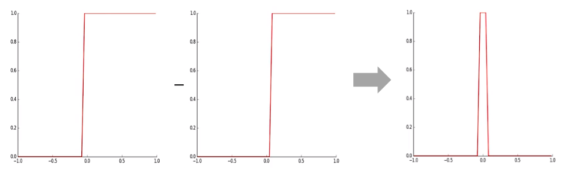

*If we can get the series of these towers, then we can approximate any true function between input and output.*

*Can we come up with a neural network to represent this operation of subtracting one sigmoid function from another?.*

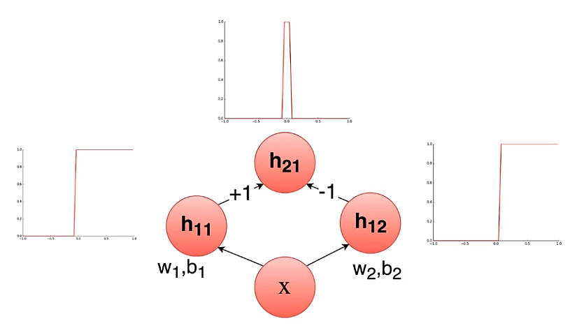

*if we have an input x and it is passed through the two sigmoid neurons and the output from these two neurons are combined in another neuron with weights +1 and -1 i.e… same is as subtracting these two outputs, then we will get our tower. Now you can see that we have our building block ready which is a connection of three sigmoid neurons. If we can construct many such building blocks and add all of them up, we can approximate any complex true relationship between input and output. This is called the **representational power of deep neural networks**, to approximate any kind of relationship between input and output.*

## *What is Activation Function?*

*Activation functions are the functions which helps to determine the output of a neural network. These type of functions are attached to each neuron in the network, and determines whether it should be activated or not, based on whether each neuron’s input is relevant for the model’s prediction.*

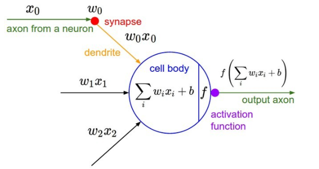

*In simple term , it calculates a “weighted sum(Wi)” of its input(xi), adds a bias and then decides whether it should be “fired” or not.*

*All the input Xi’s are multiplied with their weight Wi’s assigned to each link and summed together along with Bias b.* *Note : Xi’s and Wi’s are vectors and b is scalar.*

*Let Y be summation of ( (Wi*Xi) + b )*

*The value of Y can be anything ranging from -inf to +inf. Meaning it has lot of information ,now neuron must know to distinguish between the “useful” and “not -so-useful” information.To build this sense into our network we add ‘activation function (f)’— Which will decide whether the information passed is useful or not based on the result it get fired.*

*The activation function is a mathematical “gate” in between the input feeding the current neuron and its output going to the next layer. It can be as simple as a step function that turns the neuron output on and off, depending on a rule or threshold.*

*Neural networks use non-linear activation functions, which can help the network learn complex data, compute and learn almost any function representing a question, and provide accurate predictions. Important use of any Activation function is to introduce non-linear properties to our Network.*

### *Properties of Activation Function*

- *Derivative or Differential* *: Should Change in y-axis w.r.t. change in x-axis.It is also known as slope.(Back prop)*
- *Monotonic function* *: The function should be either entirely non-increasing or non-decreasing.*

### *Activation function Types*

- *Linear function*
- *Binary Step function*
- *Non-Linear function*

## *Linear Function*

*A linear activation function takes the form:* *y=mx+c ( m is line equation represents W and c is represented as b in neural nets so equation can be modified as y=Wx+b)*

*It takes the inputs (Xi’s), multiplied by the weights(Wi’s) for each neuron, and creates an output proportional to the input. In simple term, weighted sum input is proportional to output.*

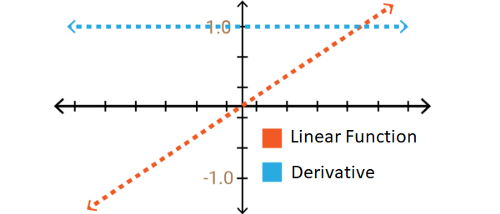

*As mentioned above , activation function should hold some properties with fails in linear function.*

*Problem with Linear function,*

- *Differential result is constant.*

*Differential of linear function is constant and has no relation with the input.Which implies weights and bias will be updated during the backprop but the updating factor (gradient) would be the same.*

- *All layers of the neural network collapse into one.*

*Linear activation functions, no matter how many layers in the neural network, the last layer will be a linear function of the first layer — Meaning Output of the first layer is same as the output of the nth layer.*

- *Doesnot holds true with Universal Approximation Theorum.*

*A neural networks with a linear activation function is simply a linear regression model.*

*Pros and Cons* *: Linear function has limited power and ability to handle complexity.It can be used for simple task like interpretability.*

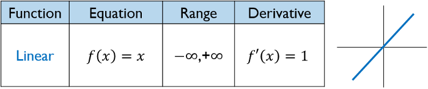

## *Binary Step Function*

*Binary step function are popular known as **“Threshold function”**. It is very simple function.*

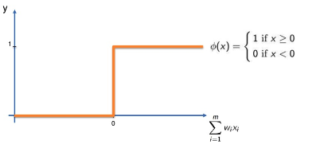

*Pros and Cons*

- *The gradient(differential ) of the binary step function is zero,which is the very big problem in back prop for weight updation.*
- *Another problem with a step function is that it can handle binary class problem alone.(Though with some tweak we can use it for multi-class problem)*

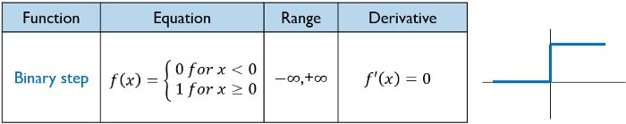

## *Non-Linear Function*

*The deep learning rocketing to the sky because of the non-linear functions.Most modern neural network use the non-linear function as their activation function to fire the neuron. Reason being they allow the model to create complex mappings between the network’s inputs and outputs, which are essential for learning and modeling complex data, such as images, video, audio, and data sets which are non-linear or have high dimensionality.*

*Advantage of Non-linear function over the Linear function*

- *Differential are possible in all the non -linear function.*
- *Stacking of network is possible , which helps us in creating the deep neural nets.*

*Non-linear Activation Function Types* *The Nonlinear Activation Functions are mainly divided on the basis of their range or curves.*

### *Sigmoid or Logistic Activation Function*

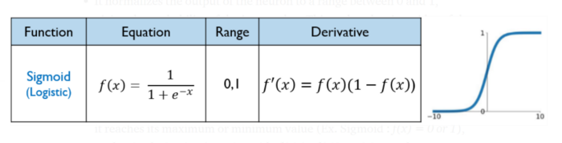

[figure not shown]

- *The output of the sigmoid function always ranges between 0 and 1 .*
- *Sigmoid is S-shaped , ‘monotonic’ & ‘differential’ function.*
- *Derivative /Differential of the sigmoid function (f’(x)) will lies between 0 and 0.25.*
- *Derivative of the sigmoid function is not “monotonic”.*

*Cons:*

- *Derivative of sigmoid function suffers “**Vanishing gradient problem**” - for very high or very low values of X, there is almost no change to the prediction, causing a vanishing gradient problem. This can result in the network refusing to learn further, or being too slow to reach an accurate prediction.*
- *Sigmoid function in not “zero-centric”.This makes the gradient updates go too far in different directions. 0 < output < 1, and it makes optimization harder.*
- *Slow convergence- as its computationally heavy.(Reason use of exponential math function )*

*Sigmoid is very popular in classification problems.*

#### *Saturation problem*

*A neuron is said to be saturated if it reaches to its peak value either maximum or minimum.*

*Saturation when f(x) = 0 or 1 then f’(x) = f(x)(1- f(x)) = 0*

*Why do we care about Saturation?*

*Refer to the below neural network where let us assume weight w211 needs to be updated during backpropagation using gradient descent update rule.*

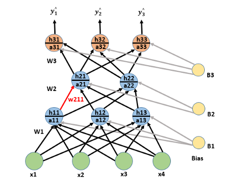

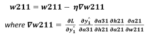

*Now if h21 is found to be 1 then its derivative will be 0. So there is no any update in weight w211, this problem is known as **vanishing gradient** problem. The gradient of weight vanishes or goes down to zero.*

*So using logistic activation function, the saturated neuron may cause the gradient to vanish and therefore the network refuses to learn or keep learning at a very small rate.*

#### *Not a zero-centered function*

*A function having an equal mass on both the sides of zero line (x-axis) is known as a zero-centered function. Or in other words, in a zero-centered function, the output can be either negative or positive.*

*In the case of logistic activation function, the output is always positive and the output is always accumulated only towards one side (positive side) so it is not a zero-centered function.*

*Why do we care about zero-centered functions?*

*Let us assume weight w311 and w312 needs to be updated during backpropagation using gradient descent update rule.*

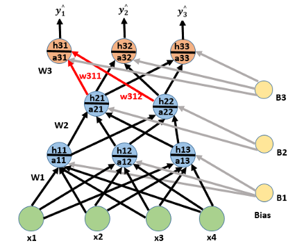

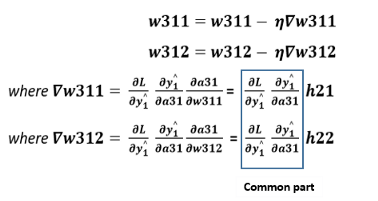

*h21 and h22 will be always positive due to the logistic activation function. The value of the gradient of w311and w312 can be positive or negative depending on the value of the common part.*

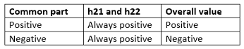

*So the gradient of all the weights connected to the same neuron is either positive or negative. Hence during update rule, these weights are only allowed to move in certain directions, not in all the possible directions. It makes the optimization harder.*

*It is similar to a situation where you are only allowed to move left and forward, not allowed to move right and backward then it is very hard to reach the desired destination.*

### *tanh Function*

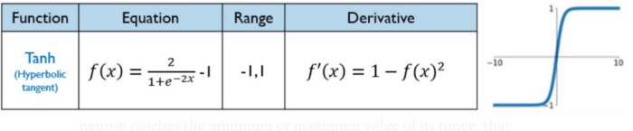

[figure not shown]

*Tanh is a hyperbolic tangent function. The curves of tanh function and sigmod function are relatively similar. Tanh is the modified version of sigmoid function.Hence have similar properties of sigmoid function.*

[figure not shown]

*Cons:*

- *Derivative of Tanh function suffers “Vanishing gradient and Exploding gradient problem”.*
- *Slow convergence- as its computationally heavy.(Reason use of exponential math function )*

*Tanh is preferred over the sigmoid function since it is zero centered and the gradients are not restricted to move in a certain direction.*

*In general binary classification problems, the tanh function is used for the hidden layer and the sigmod function is used for the output layer. However, these are not static, and the specific activation function to be used must be analyzed according to the specific problem, or it depends on debugging.*

### *ReLU (Rectified Linear Units) Function*

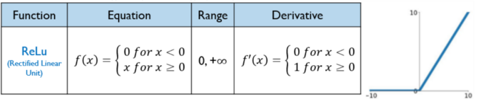

[figure not shown]

*ReLU is the non-linear activation function that has gained popularity in AI. ReLu function is also represented as f(x) = max(0,x).*

- *The function and its derivative both are monotonic.*
- *Main advantage of using the ReLU function- It does not activate all the neurons at the same time.*
- *Computationally efficient*
- *Derivative /Differential of the Tanh function (f’(x)) will be 1 if f(x) > 0 else 0.*
- *Converge very fast*

*Cons:*

*Problem of Dying neuron/Dead neuron* *: As the ReLu derivative f’(x) is not 0 for the positive values of the neuron (f’(x)=1 for x ≥ 0), ReLu does not saturate (exploid) and no dead neurons (Vanishing neuron)are reported. Saturation and vanishing gradient only occur for negative values that, given to ReLu, are turned into 0- This is called the problem of dying neuron.*

### *Leaky ReLU Function*

[figure not shown]

[figure not shown]

[figure not shown]

*Leaky ReLU function is nothing but an improved version of the ReLU function with introduction of “constant slope”.*

- *Leaky ReLU is defined to address problem of dying neuron/dead neuron.*
- *Problem of dying neuron/dead neuron is addressed by introducing a small slope having the negative values scaled by α enables their corresponding neurons to “stay alive”.*
- *The function and its derivative both are monotonic*
- *It allows negative value during back propagation*
- *It is efficient and easy for computation.*
- *Derivative of Leaky is 1 when f(x) > 0 and ranges between 0 and 1 when f(x) < 0.*

*Cons:*

- *Leaky ReLU does not provide consistent predictions for negative input values.*

*In theory, Leaky ReLU has all the advantages of ReLU, plus there will be no problems with Dead ReLU, but in actual operation, it has not been fully proved that Leaky ReLU is always better than ReLU.*

### *ELU (Exponential Linear Units) Function*

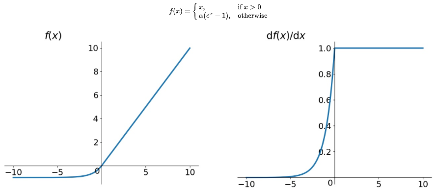

*ELU is also proposed to solve the problems of ReLU. Obviously, ELU has all the advantages of ReLU, and:*

- *ELU is also proposed to solve the problem of dying neuron.*
- *No Dead ReLU issues*
- *Zero-centric*

*Cons:*

- *Computationally intensive.*
- *Similar to Leaky ReLU, although theoretically better than ReLU, there is currently no good evidence in practice that ELU is always better than ReLU.*
- *f(x) is monotonic only if alpha is greater than or equal to 0.*
- *f’(x) derivative of ELU is monotonic only if alpha lies between 0 and 1.*
- *Slow convergence due to exponential function.*

### *PRelu (Parametric ReLU) Function*

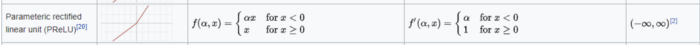

[figure not shown]

*PReLU is also an improved version of ReLU. In the negative region, PReLU has a small slope, which can also avoid the problem of ReLU death. Compared to ELU, PReLU is a linear operation in the negative region. Although the slope is small, it does not tend to 0, which is a certain advantage.*

- *The idea of leaky ReLU can be extended even further.*
- *Instead of multiplying x with a constant term we can multiply it with a “hyperparameter (a-trainable parameter)” which seems to work better the leaky ReLU. This extension to leaky ReLU is known as Parametric ReLU.*
- *The parameter α is generally a number between 0 and 1, and it is generally relatively small.*
- *Have slight advantage over Leaky Relu due to trainable parameter.*
- *Handle the problem of dying neuron.*

*Cons:*

- *Same as leaky Relu.*
- *f(x) is monotonic when a> or =0 and f’(x) is monotonic when a =1*

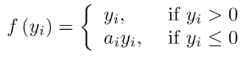

*We look at the formula of PReLU. The parameter α is generally a number between 0 and 1, and it is generally relatively small, such as a few zeros. When α = 0.01, we call PReLU as Leaky Relu , it is regarded as a special case PReLU it.*

*Above, yᵢ is any input on the ith channel and aᵢ is the negative slope which is a learnable parameter.*

- *if aᵢ=0, f becomes ReLU*
- *if aᵢ>0, f becomes leaky ReLU*
- *if aᵢ is a learnable parameter, f becomes PReLU*

### *Maxout*

*The Maxout activation is a generalization of the ReLU and the leaky ReLU functions. It is a learnable activation function.*

*Maxout can be seen as adding a layer of activation function to the deep learning network, which contains a parameter k. Compared with ReLU, sigmoid, etc., this layer is special in that it adds k neurons and then outputs the largest activation value. value.*

### *Swish (A Self-Gated) Function*

[figure not shown]

- *Google Brain Team has proposed a new activation function, named Swish, which is simply f(x) = x · sigmoid(x).*
- *Their experiments show that Swish tends to work better than ReLU on deeper models across a number of challenging data sets.*
- *The curve of the Swish function is smooth and the function is differentiable at all points. This is helpful during the model optimization process and is considered to be one of the reasons that swish outperforms ReLU.*
- *Swish function is “not monotonic”. This means that the value of the function may decrease even when the input values are increasing.*
- *Function is unbounded above and bounded below.*

*“Swish tends to continuously match or outform the ReLu”*

*Note that the output of the swish function may fall even when the input increases. This is an interesting and swish-specific feature.(Due to non-monotonic character)*

*f(x)=2x*sigmoid(beta*x)*

*If we think that beta=0 is a simple version of Swish, which is a learnable parameter, then the sigmoid part is always 1/2 and f (x) is linear. On the other hand, if the beta is a very large value, the sigmoid becomes a nearly double-digit function (0 for x<0,1 for x>0). Thus f (x) converges to the ReLU function. Therefore, the standard Swish function is selected as beta = 1. In this way, a soft interpolation (associating the variable value sets with a function in the given range and the desired precision) is provided.*

*Swish's design was inspired by the use of sigmoid functions for gating in LSTMs and highway networks. We use the same value for gating to simplify the gating mechanism, which is called **self-gating**.*

*The advantage of self-gating is that it only requires a simple scalar input, while normal gating requires multiple scalar inputs. This feature enables self-gated activation functions such as Swish to easily replace activation functions that take a single scalar as input (such as ReLU) without changing the hidden capacity or number of parameters.*

1) *Unboundedness (unboundedness) is helpful to prevent gradient from gradually approaching 0 during slow training, causing saturation. At the same time, being bounded has advantages, because bounded active functions can have strong reguairzation, and larger negative inputs will be resolved.*

2) *At the same time, smoothness also plays an important role in optimization and generalization.*

### *Softmax*

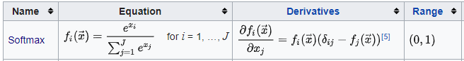

*The “softmax” function is also a type of sigmoid function but it is very useful to handle multi-class classification problems.*

*“Softmax can be described as the combination of multiple sigmoidal function.”*

*“Softmax function returns the probability for a datapoint belonging to each individual class.”*

*For an arbitrary real vector of length K, Softmax can compress it into a real vector of length K with a value in the range (0, 1), and the sum of the elements in the vector is 1.*

*Softmax is different from the normal max function: the max function only outputs the largest value, and Softmax ensures that smaller values have a smaller probability and will not be discarded directly. It is a "max" that is "soft".*

*The denominator of the Softmax function combines all factors of the original output value, which means that the different probabilities obtained by the Softmax function are related to each other.*

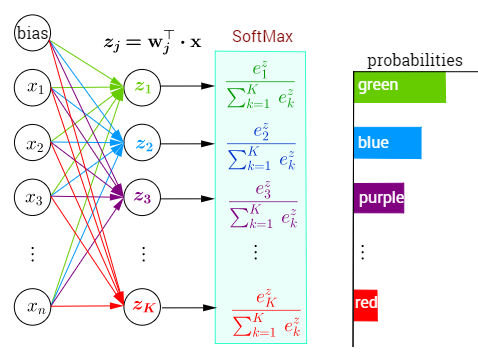

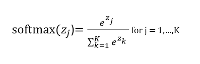

*While building a network for a multiclass problem, the output layer would have as many neurons as the number of classes in the target.*

*“Note that the sum of all the values is 1.”*

*In the case of binary classification, for Sigmoid, there are:*

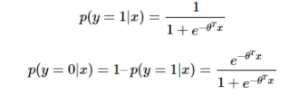

*For Softmax with K = 2, there are:*

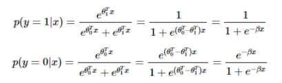

*can be seen that in the case of binary classification, Softmax is degraded to Sigmoid.*

### *Softplus*

[figure not shown]

*The softplus function is similar to the ReLU function, but it is relatively smoother.Function of Softplus or SmoothRelu:*

*f(x) = ln(1+exp x)*

*Function value ranges from (0, + inf).Both f(x) and f’(x) are monotonic.*

## *Which one is better to use ? How to choose a right one?*

*We can’t differentiate between activation function.Each activation function as its own pro’s and con’s.All the good and bad will be decided based on the trail.*

*But based on the properties of the problem we might able to make a better choice for easy and quicker convergence of the network.*

- *Sigmoid functions and their combinations generally work better in the case of classification problems*
- *Sigmoids and tanh functions are sometimes avoided due to the vanishing gradient problem*
- *ReLU activation function is widely used in modern era.*
- *In case of dead neurons in our networks due to ReLu then leaky ReLU function is the best choice*
- *ReLU function should only be used in the hidden layers*

*“As a rule of thumb, one can begin with using ReLU function and then move over to other activation functions in case ReLU doesn’t provide with optimum results”.*

## *Vanishing Gradient Problem*

*Vanishing Gradient Problem is a difficulty found in training certain Artificial Neural Networks with gradient based methods (e.g Back Propagation). In particular, this **problem makes it really hard to learn and tune the parameters of the earlier layers in the network**. This problem becomes **worse** as the **number of layers** in the architecture **increases**.*

*This is not a fundamental problem with neural networks - it's a problem with gradient based learning methods **caused by certain activation functions**. Let's try to intuitively understand the problem and the cause behind it.*

*Recall the sigmoid function, one that was almost always used as an activation function for ANNs in a classification context:*

*The sigmoid function is useful because it “squeezes” any input value into an output range of (0, 1) (where it asymptotes). This is perfect for representations of probabilities and classification.*

*Let’s take a look at the derivative of the sigmoid function.* *f(x)*(1-f(x)*

[figure not shown]

[figure not shown]

*Looks decent, you say. Look closer. The maximum point of the function is 1/4, and the function horizontally asymptotes at 0. In other words, the output of the derivative of the cost function is always between 0 and 1/4. In mathematical terms, the range is (0, 1/4].*

*Now, let’s move on to the structure of a neural network and backprop and their implications on the size of gradients.*

[figure not shown]

*Recall this general structure for a simple, univariate neural network. Each neuron or “activity” is derived from the previous: it is the previous activity multiplied by some weight and then fed through an activation function. The input, of course, is the notable exception. The error box J at the end returns the aggregate error of our system. We then perform backpropagation to modify the weights through gradient descent such that the output of J is minimized.*

*To calculate the derivative to the first weight, we used the chain rule to “backpropagate” like so:*

[figure not shown]

*Let’s focus on these individual derivatives:*

[figure not shown]

*With regards to the first derivative — since the output is the activation of the 2nd hidden unit, and we are using the sigmoid function as our activation function, then the derivative of the output is going to contain the derivative of the sigmoid function. In specific, the resulting expression will be:*

[figure not shown]

*The same applies for the second:*

[figure not shown]

*In both cases, the derivative contains the derivative of the sigmoid function. Now, let’s put those together:*

[figure not shown]

*Recall that the derivative of the sigmoid function outputs values between 0 and 1/4. By multiplying these two derivatives together, we are multiplying two values in the range (0, 1/4]. Any two numbers between 0 and 1 multiplied with each other will simply result in a smaller value. For example, 1/3 × 1/3 is 1/9.*

*Now, look at the magnitude of the terms in our expression:*

[figure not shown]

*This neural network isn’t that deep. But imagine a deeper one used in an industrial application. As we backpropagate further back, we’d have many more small numbers partaking in a product, creating an even tinier gradient! Thus, with deep neural nets, the vanishing gradient problem becomes a major concern.*

*How do we solve this?*

*Rectified Linear Unit (ReLU)*

[figure not shown]

*Another way of writing the ReLU function is like so:*

[figure not shown]

*In other words, when the input is smaller than zero, the function will output zero. Else, the function will mimic the identity function. It’s very fast to compute the ReLU function.*

*It doesn’t take a genius to calculate the derivative of this function. When the input is smaller than zero, the output is always equal to zero, and so the rate of change of the function is zero. When the input is greater or equal to zero, the output is simply the input, and hence the derivative is equal to one:*

[figure not shown]

*If we were to graph this derivative, it would look exactly like a typical step function:*

[figure not shown]

*So, it’s solved! Our derivatives will no longer vanish, because the activation function’s derivative isn’t bounded by the range (0, 1).*

*ReLUs have one caveat though: they “die” (output zero) when the input to it is negative. This can, in many cases, completely block backpropagation because the gradients will just be zero after one negative value has been inputted to the ReLU function. This would also be an issue if a large negative bias term / constant term is learned — the weighted sum fed into neurons may end up being negative because the positive weights cannot compensate for the significance of the bias term. Negative weights also come to mind, or negative input (or some combination that gives a negative weighted sum). The dead ReLU will hence output the same value for almost all of your activities — zero.*

*A **“leaky” ReLU** solves this problem. Leaky Rectified Linear Units are ones that have a very small gradient instead of a zero gradient when the input is negative, giving the chance for the net to continue its learning.*

## *Exploding Gradient Problem*

*Exploding gradients are a problem when **large error gradients accumulate** and **result in very large updates to neural network model weights during training**. Gradients are used during training to update the network weights, but when the typically this process works best when these updates are small and controlled. When the magnitudes of the gradients accumulate, an unstable network is likely to occur, which can cause poor predicition results or even a model that reports nothing useful what so ever. There are methods to fix exploding gradients, which include **gradient clipping** and **weight regularization**, among others. This problem mainly occurs due to large values of weights, if the value of weights are higher those when multiplied by derivates of function will be higher values and eventually in the while updating the weights in previous layer its imapct will be very much high.*

*[Reference](https://www.youtube.com/watch?v=IJ9atfxFjOQ)*